# Gilleen data behavioural analyses of PDG and beads tasks

Gary Napier

12 August 2016

### Three datasets:

- PDG action for each round (compete /cooperate);
- PDG trust rating (0 = totally untrustworthy, 1 = totally trustworthy, 0.5 = unsure) and
- Beads (0 = definitely jar A, 1 = definitely jar B, 0.5 = unsure).

### Four sequences:

- PDG task: Seq A = mostly cooperative, Seq D = mostly competitive, Seq B = first half mostly cooperative switching to second half mostly competitive, and Seq C vice versa.
- Beads task: As the PDG task except ‘comptetitive’ and ‘cooperative’ replaced by ‘Jar A’ and ‘Jar B’

### Questions - Are there group differences in:

1. First half ‘draws to certainty (DTC)’ - How many trials until subjects reach maximum certainty (1 or 0) in the first half of either task. Also, how many subjects, as a proportion of group numbers, reach maximum certainty at which trial indeces?
2. Second half DTC - How many trials until subjects reach maximum certainty after the change of jar/trustworthiness in Seq B and Seq C only.
3. The initial decision whether to cooperate/compete in the PDG in all four sequences.
4. The average trust ratings on each trial the same in Seq A and Seq D (‘mostly cooperate’, ‘mostly compete’, respectively).

**————————————————————————————————-**

### **Plots of mean responses, PDG and beads tasks**

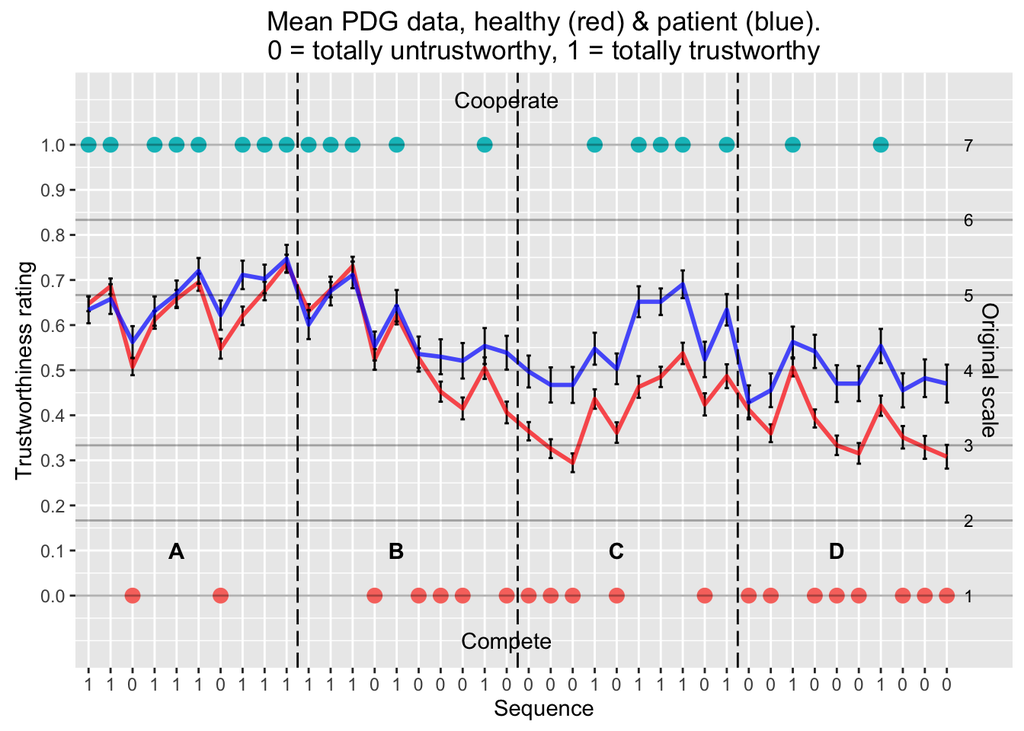

#### Measures of paranoia pre- and post-sequences in PDG game.

| t-tests on each paranoia measure, healthy vs patient | t-tests on each paranoia measure, healthy vs patient SPSpreA | t-tests on each paranoia measure, healthy vs patient SPSpostA | t-tests on each paranoia measure, healthy vs patient SPSpreB | t-tests on each paranoia measure, healthy vs patient SPSpostB | t-tests on each paranoia measure, healthy vs patient SPSpreC | t-tests on each paranoia measure, healthy vs patient SPSpostC | t-tests on each paranoia measure, healthy vs patient SPSpreD | t-tests on each paranoia measure, healthy vs patient SPSpostD |
| --- | --- | --- | --- | --- | --- | --- | --- | --- |
| t | 1.20 | -0.43 | -1.19 | 1.32 | -0.19 | 2.38 | 0.15 | 2.67 |
| df | 90.71 | 107.26 | 82.24 | 86.34 | 87.92 | 85.38 | 94.93 | 102.27 |
| p | 0.23 | 0.67 | 0.24 | 0.19 | 0.85 | 0.02 | 0.88 | 0.01 |
| d | 0.20 | 0.07 | 0.21 | 0.23 | 0.03 | 0.41 | 0.02 | 0.44 |

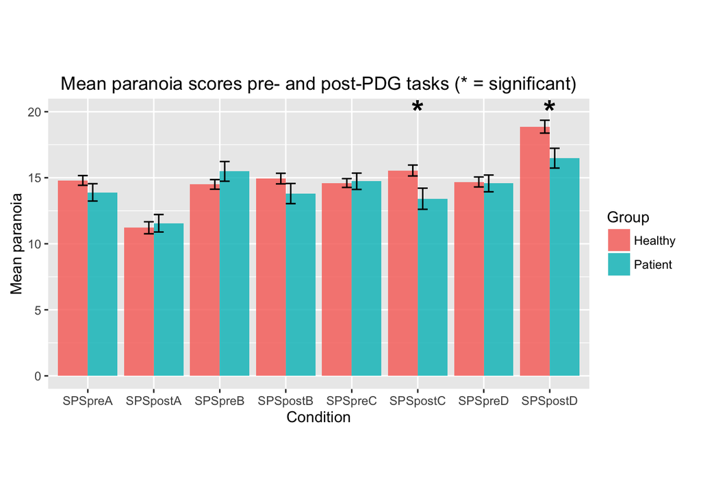

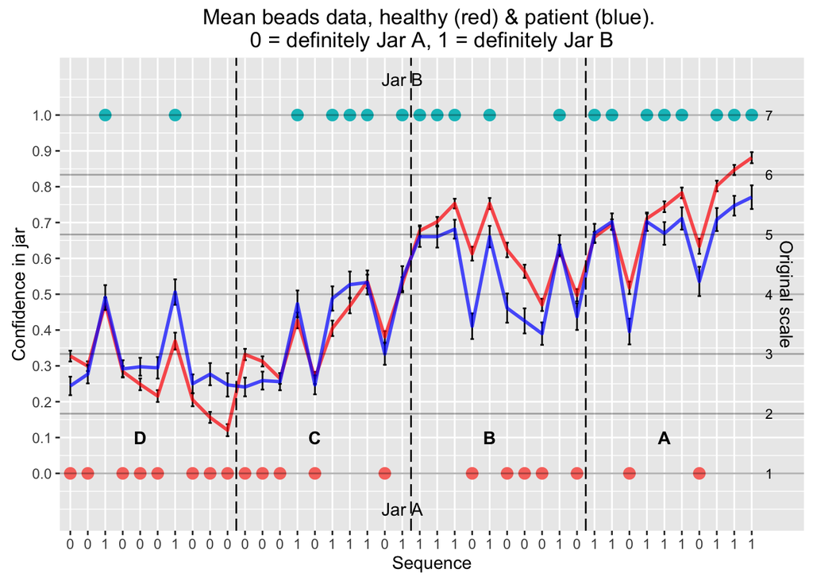

**————————————————————————————————-**

#### **1a. First half ‘draws to certainty (DTC)’ - How many trials until subjects reach maximum certainty (0 or 1; 1 or 7 in original Likert scale) in the first half of both tasks.**

##### NB - if subjects took more than 5 trials to certainty, this was counted as ‘5’, so there were **at least** 5 trials to certainty.

| Average draws to certainty over first half of all sequences PDG Healthy | Average draws to certainty over first half of all sequences PDG Patient | Average draws to certainty over first half of all sequences | Average draws to certainty over first half of all sequences Beads Healthy | Average draws to certainty over first half of all sequences Beads Patient |
| --- | --- | --- | --- | --- |
| 4.52 | 4.34 |  | 4.98 | 4.84 |

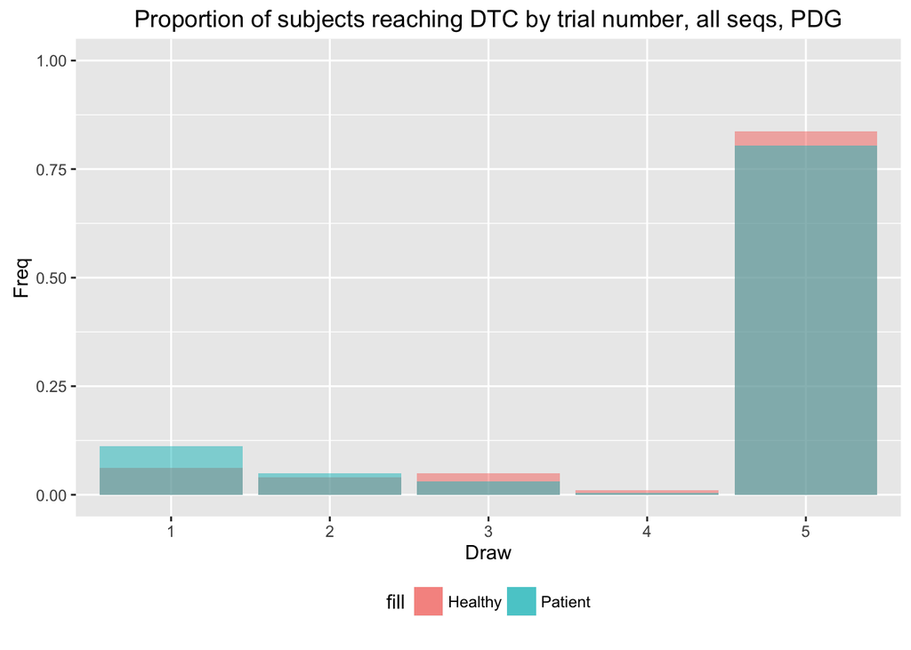

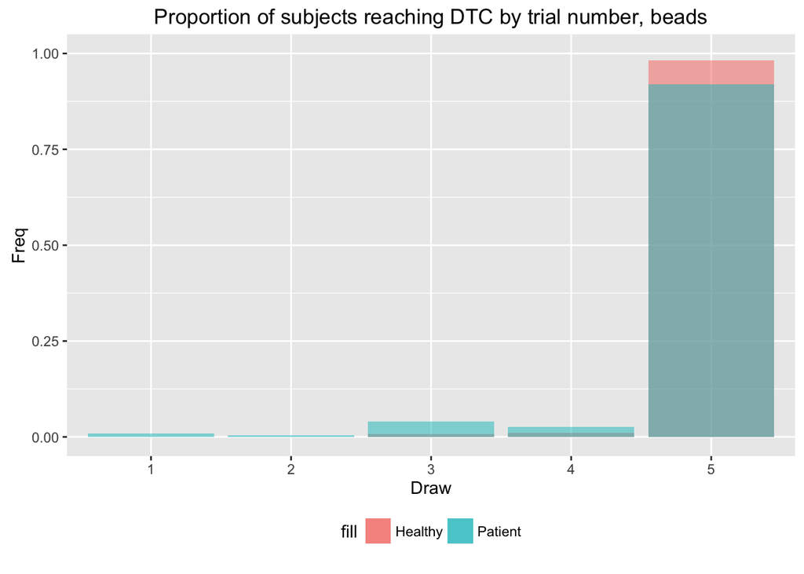

##### **Group statistics of final certainty ratings for each seq, PDG and beads.**

###### - Interpreted as the maximum individual rating for each subject.

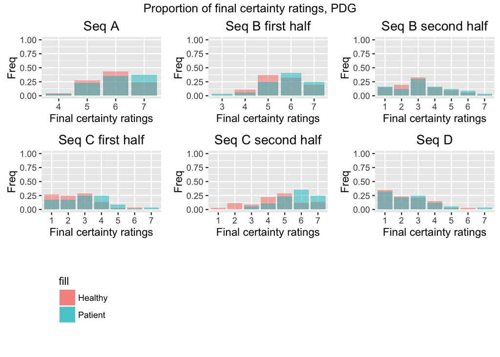

| Healthy vs patient final certainty scores, PDG | Healthy vs patient final certainty scores, PDG Healthy.mean | Healthy vs patient final certainty scores, PDG Pat.mean | Healthy vs patient final certainty scores, PDG t | Healthy vs patient final certainty scores, PDG df | Healthy vs patient final certainty scores, PDG p |
| --- | --- | --- | --- | --- | --- |
| A | 0.812 | 0.845 | -1.400 | 105.385 | 0.164 |
| B first half | 0.765 | 0.798 | -1.215 | 105.289 | 0.227 |
| B second half | 0.347 | 0.396 | -1.135 | 99.088 | 0.259 |
| C first half | 0.251 | 0.348 | -2.469 | 96.237 | 0.015 |
| C second half | 0.589 | 0.774 | -5.189 | 146.021 | 0.000 |
| D | 0.226 | 0.253 | -0.685 | 98.751 | 0.495 |

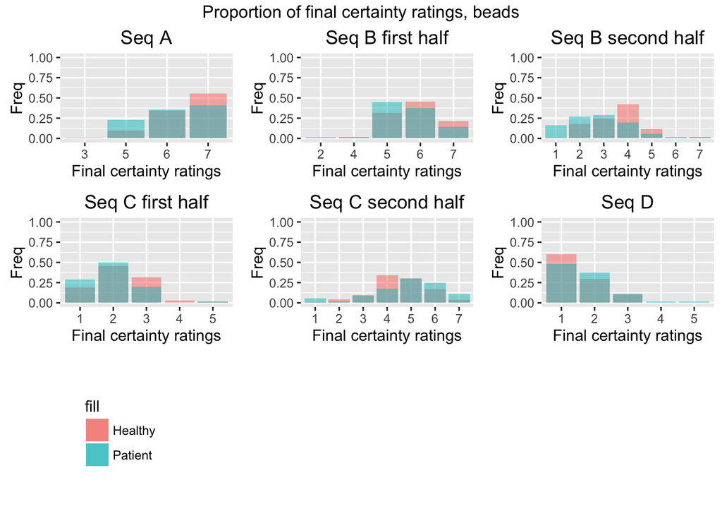

| Healthy vs patient final certainty scores, beads | Healthy vs patient final certainty scores, beads Healthy.mean | Healthy vs patient final certainty scores, beads Pat.mean | Healthy vs patient final certainty scores, beads t | Healthy vs patient final certainty scores, beads df | Healthy vs patient final certainty scores, beads p |
| --- | --- | --- | --- | --- | --- |
| A | 0.905 | 0.863 | 1.973 | 104.560 | 0.051 |
| B first half | 0.811 | 0.765 | 1.989 | 96.639 | 0.050 |
| B second half | 0.426 | 0.307 | 3.481 | 92.235 | 0.001 |
| C first half | 0.205 | 0.161 | 1.991 | 115.045 | 0.049 |
| C second half | 0.589 | 0.640 | -1.325 | 89.930 | 0.189 |
| D | 0.085 | 0.119 | -1.546 | 90.197 | 0.125 |

**————————————————————————————————-**

#### 1b. First-half DTC using lower criteria for certainty - Likert scales 2 & 6 - in both tasks.

##### NB - if subjects took more than 5 trials to certainty, this was counted as ‘5’, so there were **at least** 5 trials to certainty.

| Av draws to either 2 or 6 (Likert) over first half, all seqs PDG Healthy | Av draws to either 2 or 6 (Likert) over first half, all seqs PDG Patient | Av draws to either 2 or 6 (Likert) over first half, all seqs | Av draws to either 2 or 6 (Likert) over first half, all seqs Beads Healthy | Av draws to either 2 or 6 (Likert) over first half, all seqs Beads Patient |
| --- | --- | --- | --- | --- |
| 3.66 | 3.91 |  | 4.85 | 4.62 |

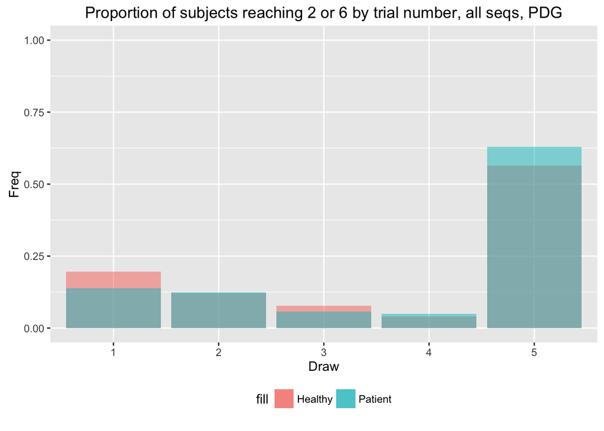

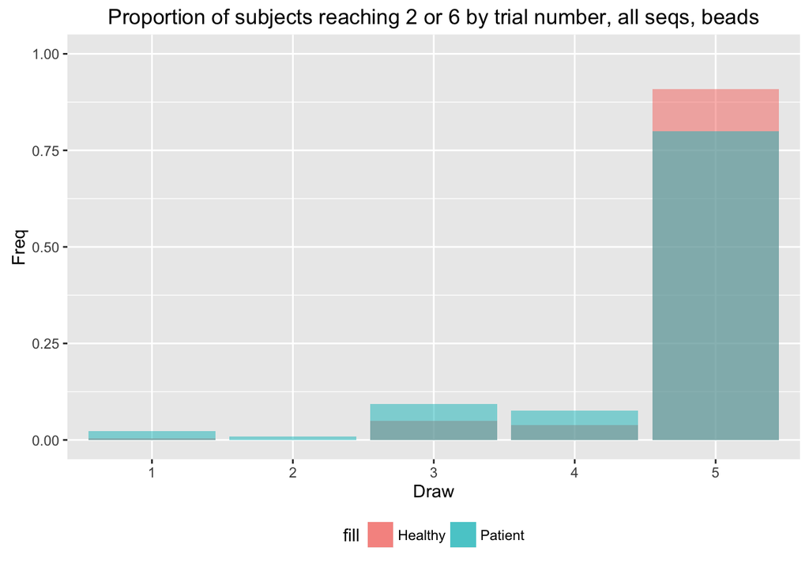

**————————————————————————————————-**

#### 2. Second half DTC - How many trials until subjects reach maximum certainty after the change of jar/trustworthiness in Seq B and Seq C only.

| Average draws to certainty over second half of seqs B & C PDG Healthy | Average draws to certainty over second half of seqs B & C PDG Patient | Average draws to certainty over second half of seqs B & C | Average draws to certainty over second half of seqs B & C Beads Healthy | Average draws to certainty over second half of seqs B & C Beads Patient |
| --- | --- | --- | --- | --- |
| 4.73 | 4.4 |  | 4.85 | 4.66 |

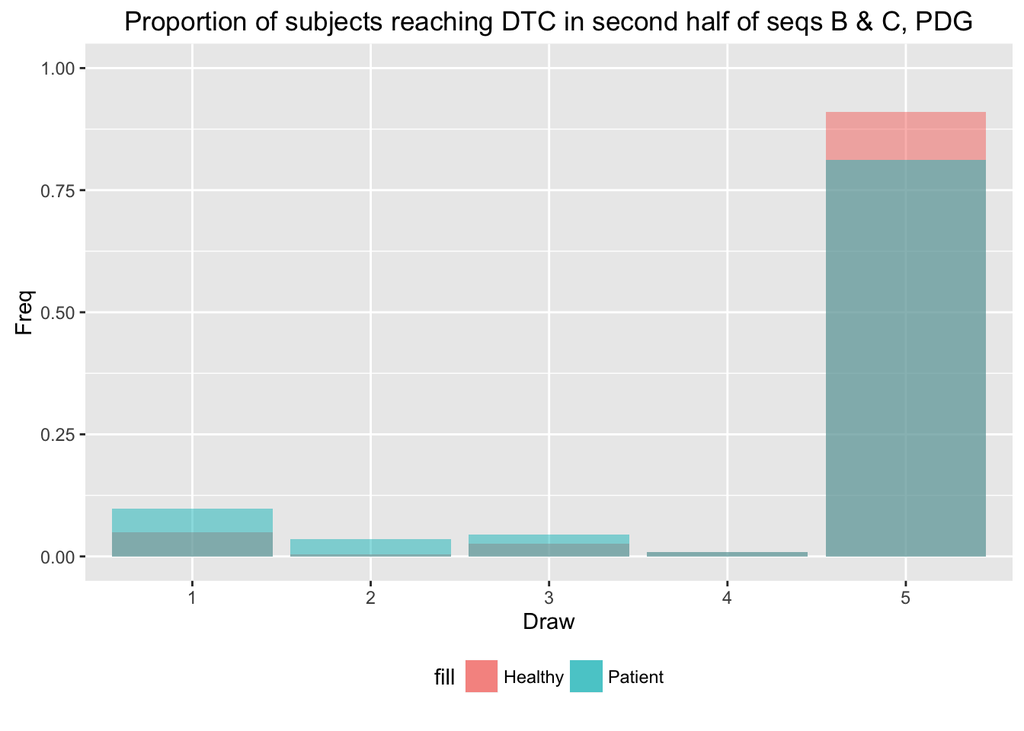

[figure not shown]

**————————————————————————————————-**

#### 3a. The *first* decision whether to cooperate/compete in the PDG, in all four sequences.

| Totals and proportions of healthy/patient’ first decisions in PDG, across all four seqs | Totals and proportions of healthy/patient’ first decisions in PDG, across all four seqs Healthy Compete | Totals and proportions of healthy/patient’ first decisions in PDG, across all four seqs Healthy Cooperate | Totals and proportions of healthy/patient’ first decisions in PDG, across all four seqs | Totals and proportions of healthy/patient’ first decisions in PDG, across all four seqs Patient Compete | Totals and proportions of healthy/patient’ first decisions in PDG, across all four seqs Patient Cooperate |
| --- | --- | --- | --- | --- | --- |
| Total first decisions (of all 4 seqs) | 179 | 269 |  | 108 | 116 |
| Proportion | 0.4 | 0.6 |  | 0.482 | 0.518 |

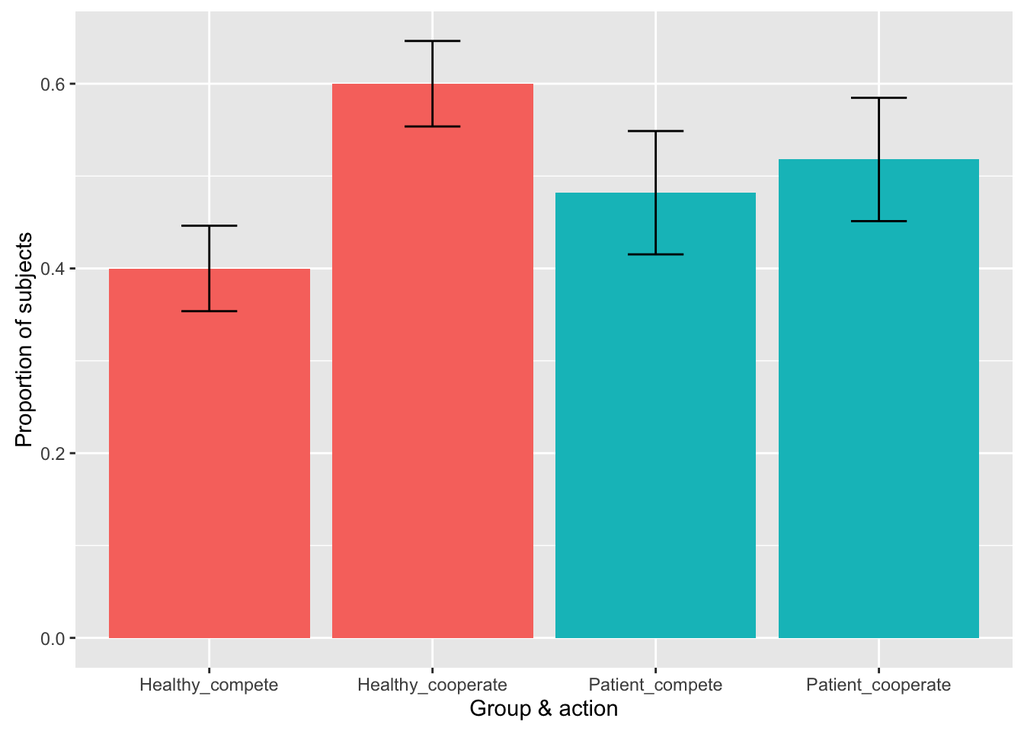

| Chi-sq test of proportions for initial action on PDG Chi-sq | Chi-sq test of proportions for initial action on PDG d.f. | Chi-sq test of proportions for initial action on PDG p |
| --- | --- | --- |
| 3.83 | 1 | 0.0503 |

**————————————————————————————————-**

#### 3b. Plot and analyses of the actions taken (cooperate/compete) in each condition over each trial and each seq of the PDG.

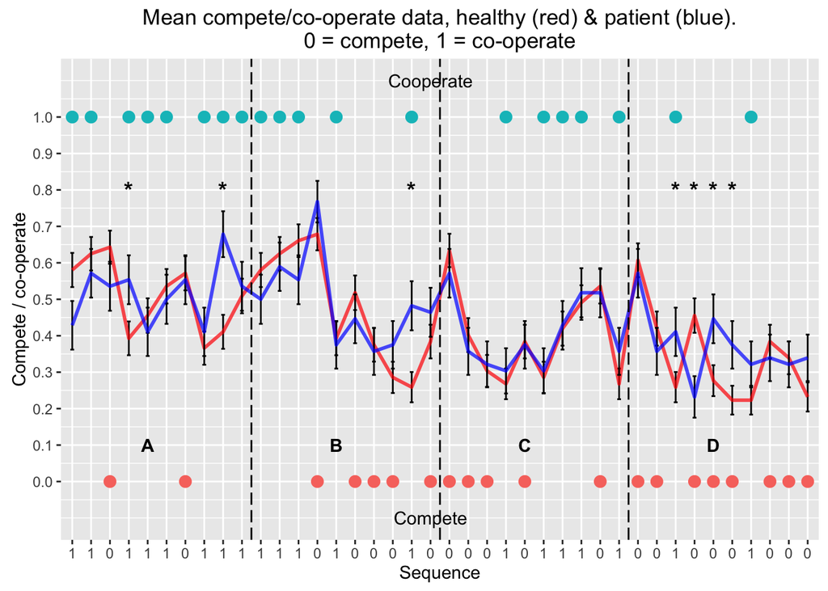

**————————————————————————————————-**

#### 4. The average trust ratings on each trial the same in Seq A and Seq D (‘mostly cooperate’, ‘mostly compete’, respectively).

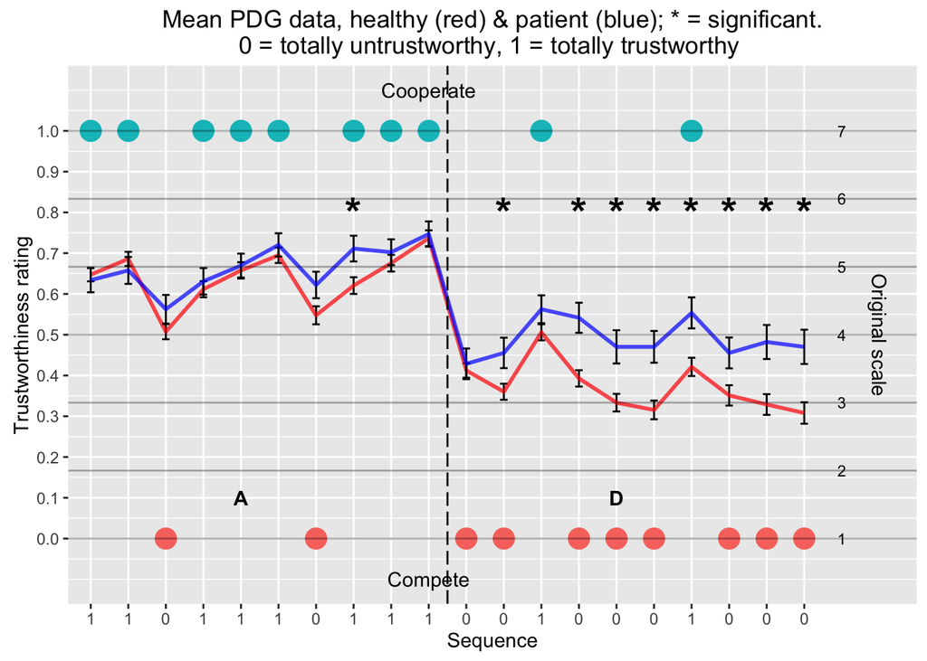

| t-tests on healthy vs patient for each draw, seq A | t-tests on healthy vs patient for each draw, seq A Draw 1 | t-tests on healthy vs patient for each draw, seq A Draw 2 | t-tests on healthy vs patient for each draw, seq A Draw 3 | t-tests on healthy vs patient for each draw, seq A Draw 4 | t-tests on healthy vs patient for each draw, seq A Draw 5 | t-tests on healthy vs patient for each draw, seq A Draw 6 | t-tests on healthy vs patient for each draw, seq A Draw 7 | t-tests on healthy vs patient for each draw, seq A Draw 8 | t-tests on healthy vs patient for each draw, seq A Draw 9 | t-tests on healthy vs patient for each draw, seq A Draw 10 |
| --- | --- | --- | --- | --- | --- | --- | --- | --- | --- | --- |
| t | 0.393 | 0.758 | -1.384 | -0.508 | -0.336 | -0.738 | -1.894 | -2.407 | -0.710 | -0.285 |
| df | 89.486 | 86.494 | 86.702 | 96.536 | 106.990 | 104.505 | 106.468 | 102.052 | 101.703 | 99.922 |
| p | 0.695 | 0.451 | 0.170 | 0.613 | 0.738 | 0.462 | 0.061 | 0.018 | 0.479 | 0.776 |

| t-tests on healthy vs patient for each draw, seq D | t-tests on healthy vs patient for each draw, seq D Draw 1 | t-tests on healthy vs patient for each draw, seq D Draw 2 | t-tests on healthy vs patient for each draw, seq D Draw 3 | t-tests on healthy vs patient for each draw, seq D Draw 4 | t-tests on healthy vs patient for each draw, seq D Draw 5 | t-tests on healthy vs patient for each draw, seq D Draw 6 | t-tests on healthy vs patient for each draw, seq D Draw 7 | t-tests on healthy vs patient for each draw, seq D Draw 8 | t-tests on healthy vs patient for each draw, seq D Draw 9 | t-tests on healthy vs patient for each draw, seq D Draw 10 |
| --- | --- | --- | --- | --- | --- | --- | --- | --- | --- | --- |
| t | -0.393 | -2.252 | -1.435 | -3.548 | -2.966 | -3.425 | -3.003 | -2.297 | -3.136 | -3.268 |
| df | 79.563 | 86.733 | 92.702 | 88.517 | 87.015 | 94.031 | 94.093 | 103.479 | 96.693 | 99.026 |
| p | 0.695 | 0.027 | 0.155 | 0.001 | 0.004 | 0.001 | 0.003 | 0.024 | 0.002 | 0.001 |

**————————————————————————————————-**

#### Other general measures

| Schizotypy - SPQBT | Schizotypy - SPQBT |
| --- | --- |
| Mean healthy | 8.22 |
| Mean patient | 11.96 |
| df | 91.65 |
| t | -4.61 |
| p | 0.00 |
| d | 0.78 |

| Working memory - LNS | Working memory - LNS |
| --- | --- |
| Mean healthy | 16.14 |
| Mean patient | 10.27 |
| df | 80.26 |
| t | 9.55 |
| p | 0.00 |
| d | 1.66 |

[output not shown]

| Education | Education |
| --- | --- |
| Mean healthy | 8.13 |
| Mean patient | 8.05 |
| df | 82.89 |
| t | 0.15 |
| p | 0.88 |
| d | 0.03 |

| Theory of mind - hinting task | Theory of mind - hinting task |
| --- | --- |
| Mean healthy | 17.98 |
| Mean patient | 16.70 |
| df | 135.59 |
| t | 2.25 |
| p | 0.03 |
| d | 0.35 |